# Visualising COVID-19

This Project will visualise the spread of COVID-19 in the early months of 2020 and is inspired by the DataCamp Visualizing COVID-19 by Richie Cotton.

First we will look into the confirmed covid cases found around the world in confirmed_cases_worldwide.csv data set.

```r
#load the relevant packages
library(readr)
library(ggplot2)
library(dplyr)

# Read datasets/confirmed_cases_worldwide.csv into confirmed_cases_worldwide
confirmed_cases <- read_csv("Downloads/Visualizing COVID-19/datasets/confirmed_cases_worldwide.csv")
# Print out confirmed_cases_worldwide
confirmed_cases
```

| date | cum_cases |
| --- | --- |
| 2020-01-22 | 555 |
| 2020-01-23 | 653 |
| 2020-01-24 | 941 |
| 2020-01-25 | 1434 |
| 2020-01-26 | 2118 |
| 2020-01-27 | 2927 |
| 2020-01-28 | 5578 |
| 2020-01-29 | 6166 |
| 2020-01-30 | 8234 |
| 2020-01-31 | 9927 |

[output cut: 46 more lines]

The confirmed cases worldwide can be represented in a line plot below by visualising the cases against the date beginning in 22th January 2020.

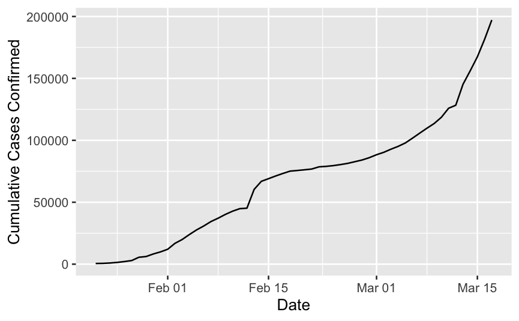

```r
# Draw a line plot of cumulative cases vs. date
# Label the y-axis
ggplot(confirmed_cases, aes(date, cum_cases)) +
  geom_line() +
  xlab("Date") +
  ylab("Cumulative Cases Confirmed")
```

```r
# Read in datasets/confirmed_cases_china_vs_world.csv
confirmed_cases_with_china <- read_csv("Downloads/Visualizing COVID-19/datasets/confirmed_cases_china_vs_world.csv")
# See the result
print(glimpse(confirmed_cases_with_china))
```

```
Rows: 112
Columns: 4
$ is_china  <chr> "China", "China", "China", "China", "China"…
$ date      <date> 2020-01-22, 2020-01-23, 2020-01-24, 2020-0…
$ cases     <dbl> 548, 95, 277, 486, 669, 802, 2632, 578, 205…
$ cum_cases <dbl> 548, 643, 920, 1406, 2075, 2877, 5509, 6087…
```

| is_china | date | cases | cum_cases |
| --- | --- | --- | --- |
| China | 2020-01-22 | 548 | 548 |
| China | 2020-01-23 | 95 | 643 |
| China | 2020-01-24 | 277 | 920 |
| China | 2020-01-25 | 486 | 1406 |
| China | 2020-01-26 | 669 | 2075 |
| China | 2020-01-27 | 802 | 2877 |
| China | 2020-01-28 | 2632 | 5509 |
| China | 2020-01-29 | 578 | 6087 |
| China | 2020-01-30 | 2054 | 8141 |
| China | 2020-01-31 | 1661 | 9802 |

[output cut: 102 more lines]

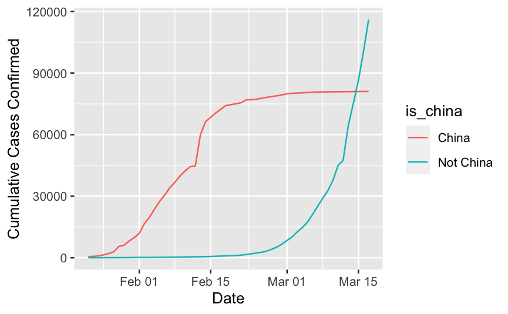

```r
# Draw a line plot of cumulative cases vs. date, grouped and colored by is_china
# Define aesthetics within the line geom
plt_cum_china_vs_world <- ggplot(confirmed_cases_with_china) +
  geom_line(aes(date, cum_cases, group = is_china, color = is_china)) +
  xlab("Date") +
  ylab("Cumulative Cases Confirmed")

# See the plot
plt_cum_china_vs_world
```

We can see that China contained a great volume of the casesIn February, the majority of cases were in China. To understand the significance of the time we will enter the landmark dates that indicate the escalation of COVID into a pandemic.

With the World Health Organisation declaring a global emergency on 30th January 2020. We have China reporting a change in the number of cases on the 13th February 2020 and then a pandemic declared on the 11th March 2020.

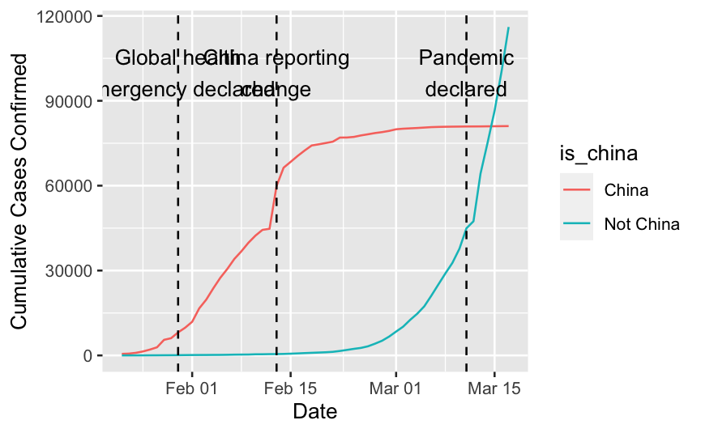

```r
#
events <- tribble(
  ~ date, ~ event,
  "2020-01-30", "Global health\nemergency declared",
  "2020-03-11", "Pandemic\ndeclared",
  "2020-02-13", "China reporting\nchange"
) %>%
  mutate(date = as.Date(date))

# Using events, add vertical dashed lines with an xintercept at date
# and text at date, labeled by event, and at 100000 on the y-axis
plt_cum_china_vs_world +
  geom_vline(aes(xintercept = date), data = events, linetype = "dashed") +
  geom_text(aes( x=date, label = event), data = events, y = 1e5)
```

A logarithmic scale will be introduced on the y axis to explore the changes in number of cases expected in the future as shown below with a trend line. We can use the trend line to predict how the number of cases worldwide, other than China, will change in the future.

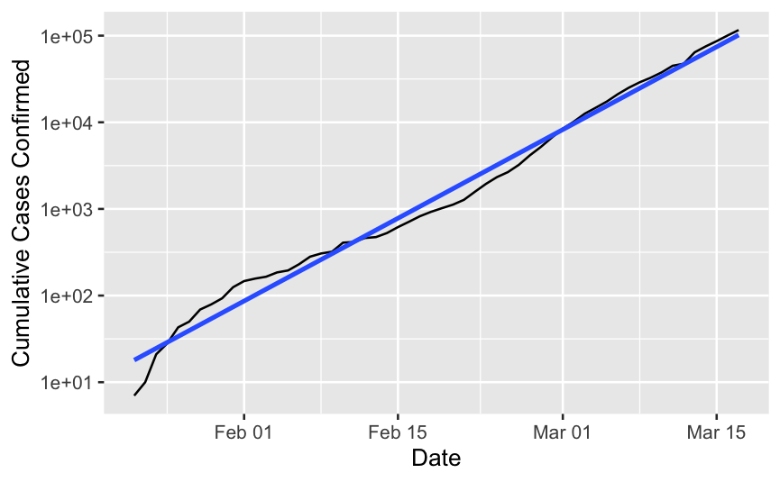

```r
# Modify the plot to use a logarithmic scale on the y-axis

# Filter confirmed_cases_with_china for not China
no_china <- confirmed_cases_with_china %>%
  filter(is_china == "Not China")

# Using not_china, draw a line plot cum_cases vs. date
# Add a smooth trend line using linear regression, no error bars
plt_worldwide_log_trend<- ggplot(no_china, aes(date, cum_cases)) +
  geom_line() +
  geom_smooth(method = "lm", se = FALSE) +
  xlab("Date") +
  ylab("Cumulative Cases Confirmed") +
  scale_y_log10()

plt_worldwide_log_trend
```

We can see that the trend line is a good fit but indicates a increasing trend line and predict a future increase in cases worldwide.

We will now explore the top seven countries worst effected by COVID-19.

```r
# read the data set for each country
confirmed_cases_by_country <- read_csv("Downloads/Visualizing COVID-19/datasets/confirmed_cases_by_country.csv")
# Group by country, summarize to calculate total cases, find the top 7
top_countries_by_cases <- confirmed_cases_by_country %>%
  group_by(country) %>%
  summarize(total_cases = max(cum_cases)) %>%
top_n(7, total_cases)
# See the result
top_countries_by_cases
```

| country | total_cases |
| --- | --- |
| France | 7699 |
| Germany | 9257 |
| Iran | 16169 |
| Italy | 31506 |
| Korea, South | 8320 |
| Spain | 11748 |
| US | 6421 |

We can visualise the change in the number of cases for the countries that have been effected the most.

```r
# Read in the dataset from datasets/confirmed_cases_top7_outside_china.csv
top7_countries_outside_china <- read_csv("Downloads/Visualizing COVID-19/datasets/confirmed_cases_top7_outside_china.csv")
# Glimpse the contents of confirmed_cases_top7_outside_china
glimpse(top7_countries_outside_china)
```

```
Rows: 2,030
Columns: 3
$ country   <chr> "Germany", "Iran", "Italy", "Korea, South",…
$ date      <date> 2020-02-18, 2020-02-18, 2020-02-18, 2020-0…
$ cum_cases <dbl> 16, 0, 3, 31, 2, 13, 13, 13, 13, 13, 13, 13…
```

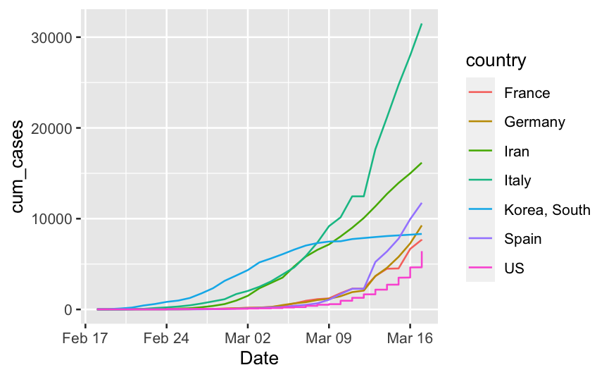

```r
# Using confirmed_cases_top7_outside_china, draw a line plot of
# cum_cases vs. date, grouped and colored by country
ggplot(top7_countries_outside_china, aes(date, cum_cases, color = country, group = country)) +
  geom_line() +
  xlab("Date")
```

```r
  ylab("Cumulative Cases Confirmed")
```

```
$y
[1] "Cumulative Cases Confirmed"

attr(,"class")
[1] "labels"
```

We can see that Italy was the country that was the most seriously effected by the virus aside from China by around 15,000 cases.